# Hypothesis Testing

Biol 607

```r
knitr::opts_chunk$set(echo = TRUE)
```

### 1) W&S Chapter 6 questions 15, 21, and 29

### 2) W&S Chapter 7 question 22 - use R to calculate a p-value

### 3) From the Lab: Many SDs and Alphas

Here’s the exercise we started in lab. Feel free to look back copiously at the lab handout if you’re getting stuck. Remember, for each step, write-out in comments what you want to do, and then follow behing with code.

Now, let’s assume an average population-wide resting heart rate of 80 beats per minute with a standard deviation of 6 BPM.

A given drug speeds people’s heart rates up on average by 5 BPM. What sample size do we need to achieve a power of 0.8?

#### 3.1) Start up your simulation

Make a simulated data frame to look at the effects of multiple sample sizes: from 1-20, with 500 simulations per sample size, and also multiple SD values, from 3 through 10 (just 3:10, no need for non-integer values). You’re going to want `crossing` with your intitial data frame of just sample sizes and a vector of sd values to start. Then generate samples from the appropriate random normal distribution.

```r
library(tidyr)
library(dplyr)
```

```r
library(ggplot2)

#make that df!
heart_sims <- crossing(sims = 1:500, n = 1:20, sd = 3:10)
```

#### 3.2) Z!

OK, now that you’ve done that, calculate the results from z-tests. Plot p by sample size, using `facet_wrap` for different SD values.

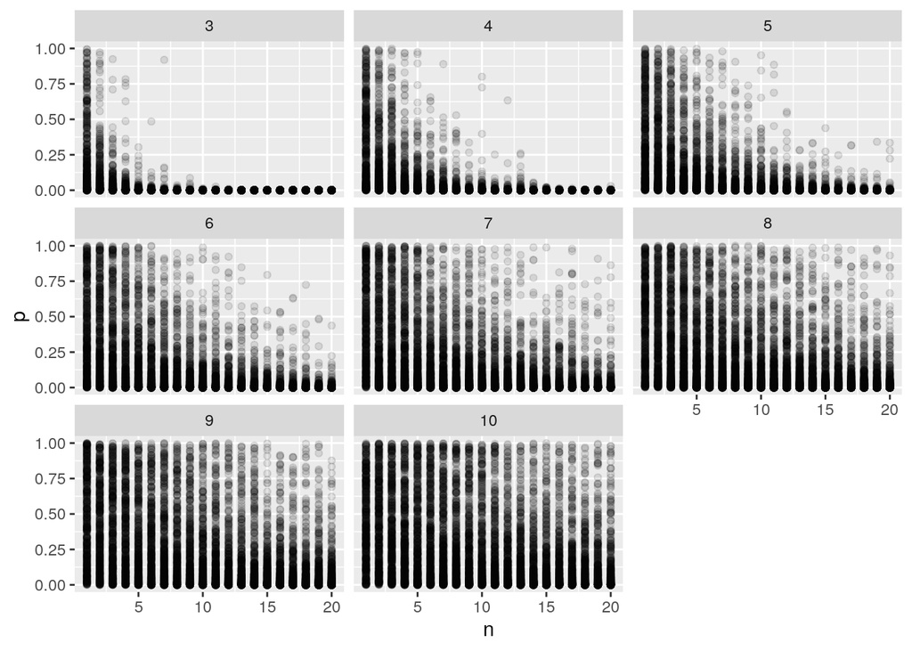

```r
heart_sims <- heart_sims %>%
  rowwise() %>%
  mutate(samp_mean = mean(rnorm(n, mean = 85, sd = sd)),
         z = (samp_mean-80)/(sd/sqrt(n)),
         p = 2*pnorm(abs(z), 0, 1, lower.tail=FALSE)) %>%
  ungroup()

qplot(n,p, data = heart_sims, alpha = I(0.1)) + facet_wrap(~sd)
```

#### 3.3) P and Power

Now plot power for an alpha of 0.05, but use color for different SD values. Include our threshold power of 0.8.

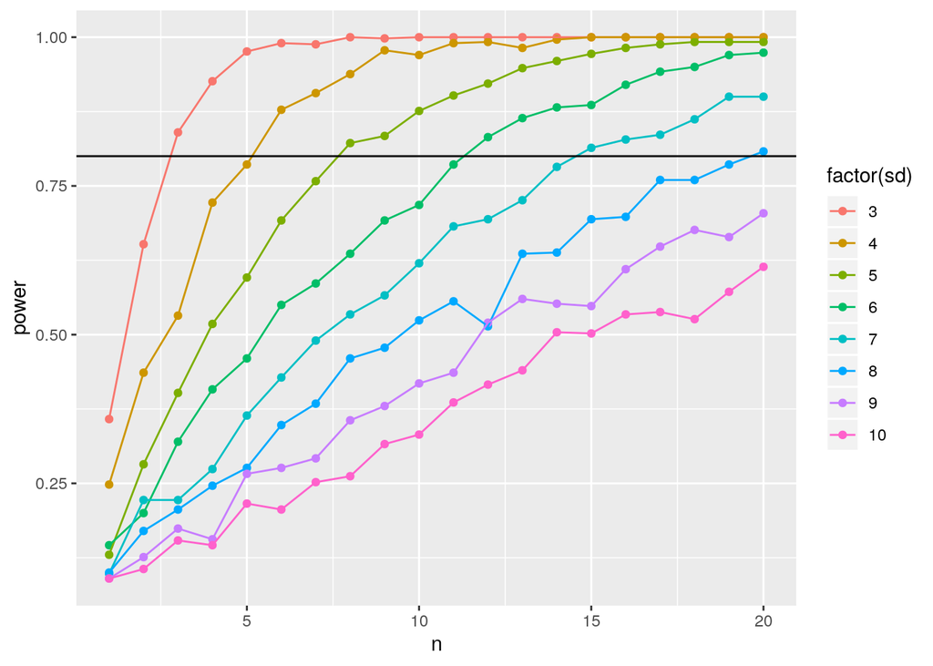

```r
heart_power <- heart_sims %>%
  group_by(n, sd) %>%
  summarize(power = 1-sum(p>0.05)/n()) %>%
  ungroup()

ggplot(heart_power,
       aes(x = n, y = power, color = factor(sd))) +
  geom_point() + geom_line() +
  geom_hline(yintercept = 0.8)
```

#### 3.4) Many alphas

Last, use `crossing` again to explore changing alphas from 0.01 to 0.1. Plot power curves with different alphas as different colors, and use faceting to look at different SDs.

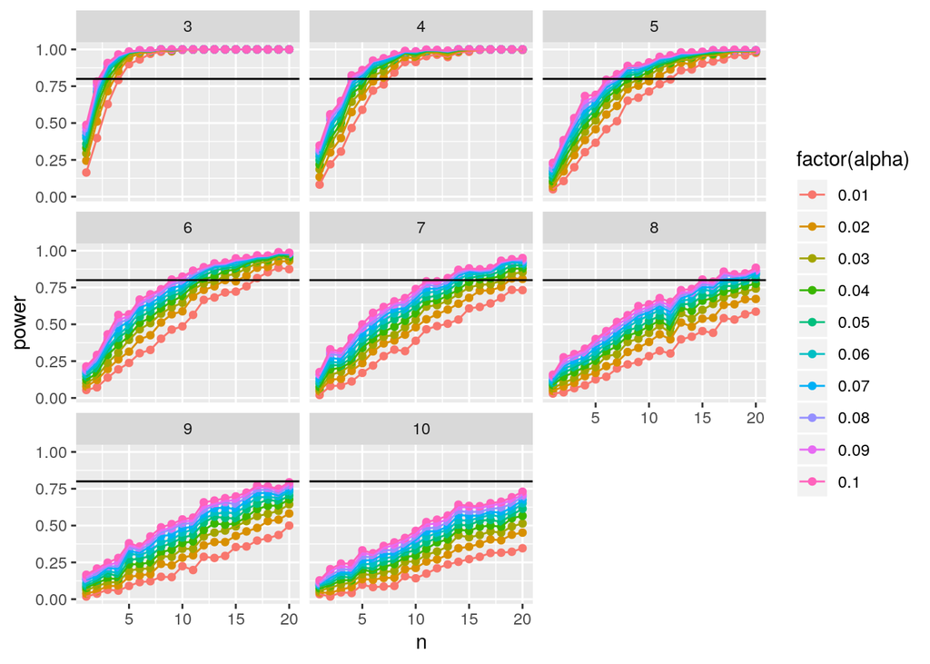

```r
heart_power_alpha <- crossing(heart_sims, alpha = seq(0.01, 0.1, 0.01)) %>%
  group_by(n, sd, alpha) %>%
  summarize(power = 1-sum(p>alpha)/n()) %>%
  ungroup()

ggplot(heart_power_alpha,
       aes(x = n, y = power, color = factor(alpha))) +
  geom_point() + geom_line() +
  geom_hline(yintercept = 0.8) +
  facet_wrap(~sd)
```

#### 3.5) What does it all mean? What do you learn about how alpha and SD affect power?

#### 3.6) How do you think that changing the effect size would affect power?

You can just answer this without coding out anything. Based on what we’ve learned so far - what do you think?